# Analysis Workflow_1

Dai Shizuka

updated 10/24/24

```r
library(stringr)
library(lubridate)
library(tidyverse)
library(seewave)
library(warbleR)
library(ggmap)
```

This document describes the workflow for analyzing recordings from a microphone array to estimate location and timing of sounds.

## 1. The Setup & Recordings

Importing the file with GPS locations of each post at each plot:

```r
locations = read.csv("Microphone Array_Analysis/micarray_trimblewaypoints_2021.csv")
```

## 2. Aligning sound files and producing multichannel recording file

- This script requires the file structure that Faiza put together (each day in separate folder, and each recording unit in separate folders labelled “TS1” through “TS4”). HOWEVER, I had to change the folder names to have the dates in ymd format (i.e., “2021-07-01_…” instead of “1July…”)
- This script can now handle cases where the trial spans two tracks. In some cases, there is a few seconds of missing sounds when this happens. In such cases, this code will generate a silent track to fill in those seconds.
- It should also handle at least some of the cases where the relevant track is missing. Right now, it does this by recognizing when the last track for that recorder started more than one hour before the target start time. In such cases, it will just generate a silent track that spans the trial for that channel. This avoids confusion of what is missing–in the multichannel file, the missing recorder will just be silent.

### 2.1. Import sound file data:

This is a file that contains info on which location, date, start and end time to extract and produce aligned multichannel files for:

```r
extract.times.dat=read.csv("sounds_to_extract_20220501.csv")
extract.times.dat$ymd=mdy(extract.times.dat$Date)
extract.times.dat
```

```
##       Date Start.Time End.Time   Colony   Nest   Treatment
## 1   7/5/21    6:31:00  6:47:00 Stripies Nest31     cowbird
## 2   7/5/21    7:11:00  7:27:00 Stripies Nest31     swallow
## 3   7/5/21    7:40:00  7:50:00 Stripies Nest46     cowbird
## 4   7/5/21    8:10:00  8:25:00 Stripies Nest46     swallow
## 5   7/5/21    8:35:00  8:50:00 Stripies Nest48     cowbird
## 6   7/5/21    9:10:00  9:25:00 Stripies Nest48     swallow
## 7   7/5/21    9:48:00 10:05:00 Stripies Nest40     cowbird
## 8   7/5/21   10:25:00 10:40:00 Stripies Nest40     swallow
## 9  7/12/21    5:00:00  5:05:00 Stripies            control
## 10 6/15/21    7:10:00  7:15:00    Bambi            control
## 11 6/17/21    9:25:00  9:30:00      PIC            control
## 12 6/23/21   11:10:00 11:15:00       BP            control
## 13 6/28/21    8:19:00  8:24:00 Stripies        alarm calls
## 14 6/30/21   12:32:00 12:49:00       BP        alarm calls
```

[output cut: 21 more lines]

### 2.2. Extract the start time from the file names

Use the list.files() function to get the names of folders in the SM4TS recordings. *I have renamed these folders with the date format that is much easier to parse: (e.g., “2021-07-01_Stripies” instead of “1July_Stripies”). This way, the dates in the folder names match the “ymd” format.

```r
rawfoldernames=list.files("SM4TS Recordings", full.names = T)
head(rawfoldernames)
```

```
## [1] "SM4TS Recordings/2021-06-11_Bambi"
## [2] "SM4TS Recordings/2021-06-12_Bambi"
## [3] "SM4TS Recordings/2021-06-13_Bambi"
## [4] "SM4TS Recordings/2021-06-14_Bambi"
## [5] "SM4TS Recordings/2021-06-15_Bambi&PIC"
## [6] "SM4TS Recordings/2021-06-16_PIC"
```

We can match up each trial to the folder we want to look at. For example, which folder should we look in to get the first trial (July 5th, 2021 at Stripies)?

```r
focal=1
#nrow(extract.times.dat)
#for(focal in 14:17){
#grep(extract.times.dat$ymd[focal], rawfoldernames)

#using this, we assign the folder to use

use.folder=rawfoldernames[grep(extract.times.dat$ymd[focal], rawfoldernames)]
use.folder
```

```
## [1] "SM4TS Recordings/2021-07-05_Stripies"
```

Now, we will extract all of the start and stop recording times for each of the recorders from that day.

The folder for each date has separate folders for each recording unit. list.files(use.folder)

However, since the filename ultimately has the recorder name too, we don’t really need the subfolder names here. We can just write a code to extract all file names in all folders within that date. Just list the .wav files (ignore the summary .txt files)

We’ll save the “full path name” version and “short path name” version separately. The full name version will be useful when we actually extract the sound files. The short name version will be useful for the next code to extract metadata.

```r
use.files.full=list.files(path=paste(use.folder, list.files(use.folder), sep="/"), pattern=".wav", full.names = T)
```

```r
use.files.short=list.files(path=paste(use.folder, list.files(use.folder), sep="/"), pattern=".wav", full.names = F)
```

**Note:** Since the recorder names are naturally in the file names, there is not really any need to sort the files into subfolders by recorder…

It turns our there is a super handy function called songmeter() function in seewav. This imports relevant data from songmeter file names

```r
file.metadata=songmeter(use.files.short)
file.metadata$filepath=use.files.full
head(file.metadata)
```

```
##     model prefix mic year month day hour min sec                time geo
## 1 SM2/SM4    TS1  NA 2021     7   5    5  55  56 2021-07-05 05:55:56  NA
## 2 SM2/SM4    TS1  NA 2021     7   5    6  55  56 2021-07-05 06:55:56  NA
## 3 SM2/SM4    TS1  NA 2021     7   5    7  55  59 2021-07-05 07:55:59  NA
## 4 SM2/SM4    TS1  NA 2021     7   5    8  56   2 2021-07-05 08:56:02  NA
## 5 SM2/SM4    TS1  NA 2021     7   5    9  56   5 2021-07-05 09:56:05  NA
## 6 SM2/SM4    TS1  NA 2021     7   5   10  56   9 2021-07-05 10:56:09  NA
##                                                           filepath
## 1 SM4TS Recordings/2021-07-05_Stripies/TS1/TS1_20210705$055556.wav
## 2 SM4TS Recordings/2021-07-05_Stripies/TS1/TS1_20210705$065556.wav
## 3 SM4TS Recordings/2021-07-05_Stripies/TS1/TS1_20210705$075559.wav
## 4 SM4TS Recordings/2021-07-05_Stripies/TS1/TS1_20210705$085602.wav
## 5 SM4TS Recordings/2021-07-05_Stripies/TS1/TS1_20210705$095605.wav
## 6 SM4TS Recordings/2021-07-05_Stripies/TS1/TS1_20210705$105609.wav
```

Ok, now let’s identify which file (or files, if the desired trial is split between two files) contains the focal trial sounds for each recorder.

Get the first trial

Convert the target start and end times into ymd_hms format, in the time zone that the computer is in…

*The time zone is set to the computer’s time zone, but it doesn’t really matter because the extracted time stamps from the file names don’t have a time zone associated. It’s just that the `ymd_hms()` function needs a time zone*

```r
extract.times.dat$start.date.time=ymd_hms(paste(extract.times.dat$ymd, extract.times.dat$Start.Time, sep=" "), tz=Sys.timezone())

extract.times.dat$end.date.time=ymd_hms(paste(extract.times.dat$ymd, extract.times.dat$End.Time, sep=" "), tz=Sys.timezone())

start=extract.times.dat$start.date.time[focal]
end=extract.times.dat$end.date.time[focal]

start
```

```
## [1] "2021-07-05 06:31:00 CDT"
```

```r
end
```

```
## [1] "2021-07-05 06:47:00 CDT"
```

```r
file.metadata.split=split(file.metadata, file.metadata$prefix)

start_and_endfile.list=lapply(file.metadata.split, function(x){
  start.file=max(which(x$time<=start))
  end.file=max(which(x$time<=end))
  c(start.file, end.file)
})
start_and_endfile.list
```

```
## $TS1
## [1] 1 1
##
## $TS2
## [1] 1 1
##
## $TS3
## [1] 1 1
##
## $TS4
## [1] 1 1
```

THIS IS COMPLEX, BUT IT LOOKS AT WHETHER THE TRIAL IS CONTAINED IN ONE FILE OR GOES ACROSS TWO FILES. IF IN ONE TRIAL, JUST READS THE SECTION OF THAT FILE. IF IT CROSSES TWO FILES, IT TAKES THE APPROPRIATE CLIPS FROM EACH FILE AND THEN CONCATENATES THE FILES

```r
clips=list()
for(i in 1:length(start_and_endfile.list)){
  if(start_and_endfile.list[[i]][1]==start_and_endfile.list[[i]][2]) {
    file.start.datetime=file.metadata.split[[i]][start_and_endfile.list[[i]][1],"time"]
    start.at=as.numeric(difftime(start,file.start.datetime, units="secs"))
    end.at=as.numeric(difftime(end,file.start.datetime, units="secs"))
    if(start.at<3600) clip=readWave(file.metadata.split[[i]]$filepath[start_and_endfile.list[[i]][1]], from=start.at, to=end.at, units="seconds") else {
      left=synth(f=44100, d=as.numeric(difftime(end,start, unit="secs")), cf=100, a=0, output="Wave")
      right=synth(f=44100, d=as.numeric(difftime(end,start, unit="secs")), cf=100, a=0, output="Wave")
      clip=stereo(left, right)
    }
    clips[[i]]=clip
  } else if(start_and_endfile.list[[i]][1]!=start_and_endfile.list[[i]][2]) {
    file1.start.datetime=file.metadata.split[[i]][start_and_endfile.list[[i]][1],"time"]
    start.at1=as.numeric(difftime(start,file1.start.datetime, units="secs"))
    end.at1=Inf
    start.at2=0
    file2.start.datetime=file.metadata.split[[i]][start_and_endfile.list[[i]][2],"time"]
    end.at2=as.numeric(difftime(end,file2.start.datetime, units="secs"))
    clip1=readWave(file.metadata.split[[i]]$filepath[start_and_endfile.list[[i]][1]], from=start.at1, to=end.at1, units="seconds")
    clip2=readWave(file.metadata.split[[i]]$filepath[start_and_endfile.list[[i]][2]], from=start.at2, to=end.at2, units="seconds")
    missing.time=as.numeric(difftime(end,start, unit="secs"))-(duration(clip1)+duration(clip2))
    if(missing.time>0) {
      sil_left=synth(f=44100,d=missing.time, cf=100,a=0, output="Wave")
      sil_right=synth(f=44100,d=missing.time, cf=100,a=0, output="Wave")
      sil_stereo=stereo(sil_left, sil_right)
      clips[[i]]=tuneR::bind(clip1, sil_stereo,clip2)
    } else clips[[i]]=tuneR::bind(clip1, clip2)
  }
}

MC_trial=WaveMC(data=list(clips[[1]]@right, clips[[2]]@left, clips[[3]]@left, clips[[4]]@left, clips[[1]]@left), samp.rate=44100, bit=16)

colnames(MC_trial)=MCnames$name[1:5]
#tweak this to get left/right microphones of TS2-4 based on colony.

#proper file name

file.date=paste(mdy(extract.times.dat$Date[focal])) %>% gsub("-","",.)

file.time.vec=extract.times.dat$Start.Time[focal] %>% str_split(pattern=":") %>% unlist() %>% str_pad(width=2, pad="0")
file.time=paste(file.time.vec[1],file.time.vec[2],file.time.vec[3], sep="")
MC_filename=paste("MC", paste(file.date, file.time, sep="$"), ".wav", sep="")
#add colony name and trial type

#UNCOMMENT HERE TO ACTUALLY SAVE THE FILE
#writeWave(MC_trial, filename=MC_filename)
```

## 3. Annotating aligned sound files

Once the multichannel file is created, we need to go through and annotate the sounds. We do this in Raven Pro.

We choose the best exemplar of a given sound across all 5 channels. and select the sound. This saves a text file that contains information on the start time, end time, and frequency range of the sound of interest.

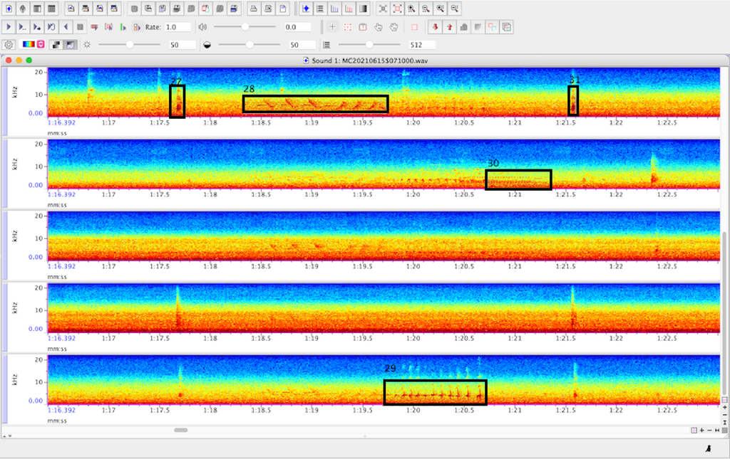

**The main questions to work on here:**

- **We should look at best strategies for annotating overlapping sounds!**

## 4. Cross-correlations to get relative time delays at each microphone

This is the most computationally intensive part of the process. The basic process proceeds as follows:

1. Extract each “template sound” annotations (see Section 3)
2. Take out a slice of recording from each channel that spans +/- 0.5 seconds before and after the sound.
3. Run cross-correlation analysis between the template sound and each of the 5 channels (including the channel that the template sound was taken from). Use 99% overlap to get high-resolution results
4. Record the peak score and peak time. If it works well, the relative delay in “peak time” across the five channels will tell us the relative time delay that we will use for triangulating the sound.

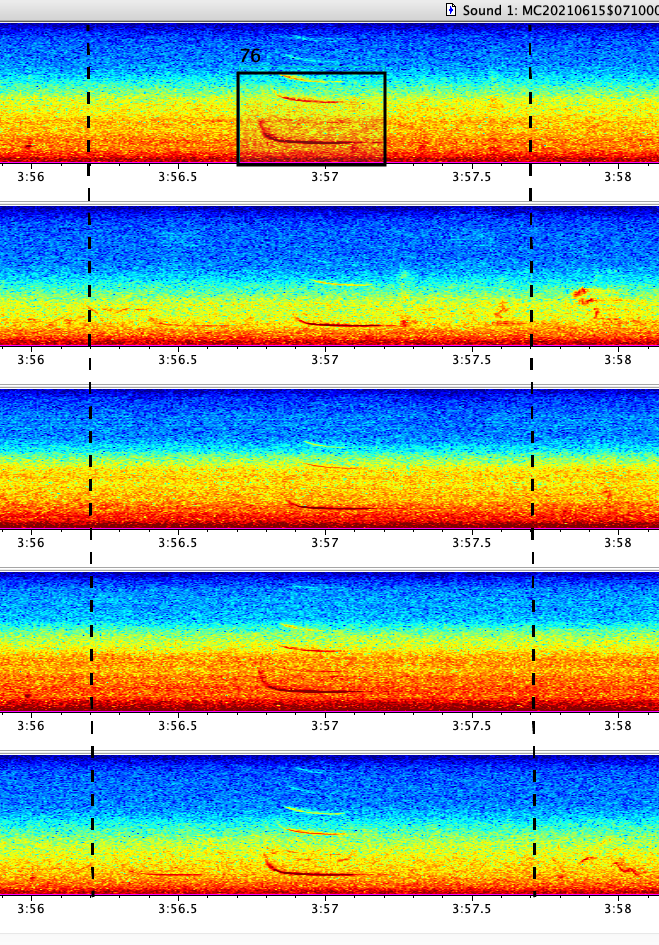

The annotated code (not run here).

```r
library(seewave)
library(lubridate)
library(warbleR)
library(stringr)
library(tidyverse)
library(foreach)
library(doParallel)
options(digits=10)

#set up parallel processing
n.cores=detectCores()
registerDoParallel(n.cores)

#find folders where the multi-channel sound files + annotation files are stored. Choose one.
folders.full=list.files("Microphone Array_Analysis",pattern="MC", full.names=T)
folders.short=list.files("Microphone Array_Analysis", pattern="MC", full.names=F)
use.folder=folders.full[7]
use.folder.short=folders.short[7]
mc_track_full=list.files(use.folder, pattern=".wav", full.names = T)
mc_track_short=list.files(use.folder, pattern=".wav", full.names = F)

annot=read.table(list.files(use.folder, pattern=".txt", full.names = T), header=T, sep="\t")

names(annot)

seltab=annot %>% mutate(sound.files=mc_track_short) %>% select(sound.files, channel=Channel, start=Begin.Time..s., end=End.Time..s., bottom.freq=Low.Freq..Hz., top.freq=High.Freq..Hz., type=Label)

seltab$selec=seq(1:nrow(seltab))
seltab$channel=as.numeric(seltab$channel)

#this creates the "template" sounds and saves them into a folder
dir.create(paste(use.folder, "templates", sep="/")) #creates a new folder called "templates" within the focal folder.
cut_sels(seltab, path=use.folder, dest.path=paste(use.folder, "templates", sep="/"))

#set up cross correlations

#first, we need to make a selection table for each template. This will include the template track and the test track clips that will be compared
#The original code creates a temporary file extracted from the templates folder, then runs the cross correlation, then deletes it. However, when running this in parallel, we end up with multiple template files ported at once, so it gets confused. Need to fix this by...

temp_names=list.files(paste(use.folder, "templates", sep="/"))
if(is.na(match(mc_track_short, temp_names))==F) temp_names=temp_names[-match(mc_track_short, temp_names)]

file_order=as.numeric(str_sub(temp_names, start=str_locate(temp_names, "-")[,1]+1, end=str_locate(temp_names, "\\.")[,1]-1))

#result.df=list()
#copy full multichannel file over to template subfolder (we need all sound files to be in same folder to run the cross correlation).

if(is.na(match(mc_track_short, list.files(paste(use.folder, "templates", sep="/"))))==T) file.copy(from=list.files(use.folder, pattern=".wav", full.names = T), to=paste(use.folder, "templates", sep="/"))

ptm=proc.time()

result.df=foreach(k = 1:nrow(annot), .inorder=TRUE) %dopar% {
  temp.df=data.frame(sound.files=temp_names[order(file_order)][k], channel=1, selec=1, start=0, end=duration_sound_files(paste(use.folder, "templates", temp_names[order(file_order)][k], sep="/"))$duration)

  track.df=data.frame(sound.files=mc_track_short, channel=1:5, selec=1:5, start=seltab$start[k]-0.5, end=seltab$end[k]+0.5)
track.df$start[which(track.df$start<0)]=0

  bp_filter=c(seltab$bottom.freq[k]/1000-0.1, seltab$top.freq[k]/1000+0.1)
  bp_filter[which(bp_filter<0)]=0
  set=rbind(temp.df, track.df)



  #run cross-correlation
  xc=list()
  for(j in 1:(nrow(set)-1)){
    xc[[j]]=cross_correlation(set[c(1,1+j),], bp=bp_filter, output="list", ovlp=99, path=paste(use.folder,"templates",sep="/"))
  }
  #xc

  # times=sapply(xc, function(x) {
  #   if(is.na(x$scores$score[1])) NA else x$scores$time[which.max(x$scores$score)]
  # })
  #times
  peak.score=sapply(xc, function(x) max(x$scores$score))
  #peak.score


  data.frame(trial=k, call_type=annot$Label[k], annotated_mic=annot$Channel[k], template=temp.df$sound.file, channel=set[2:6,"channel"], peak.time=times, peak.score=peak.score)
}

proc.time()-ptm
stopImplicitCluster()
###

save(result.df, file=paste(use.folder, "xcorr.results_99_bpfilter.rdata", sep="/"))
```

Here is an visualization of what the cross-correlation results. The lines represents cross-correlation between the template and the clip across different channels. There are only four lines here because one of the microphones was not running at this time, I think.

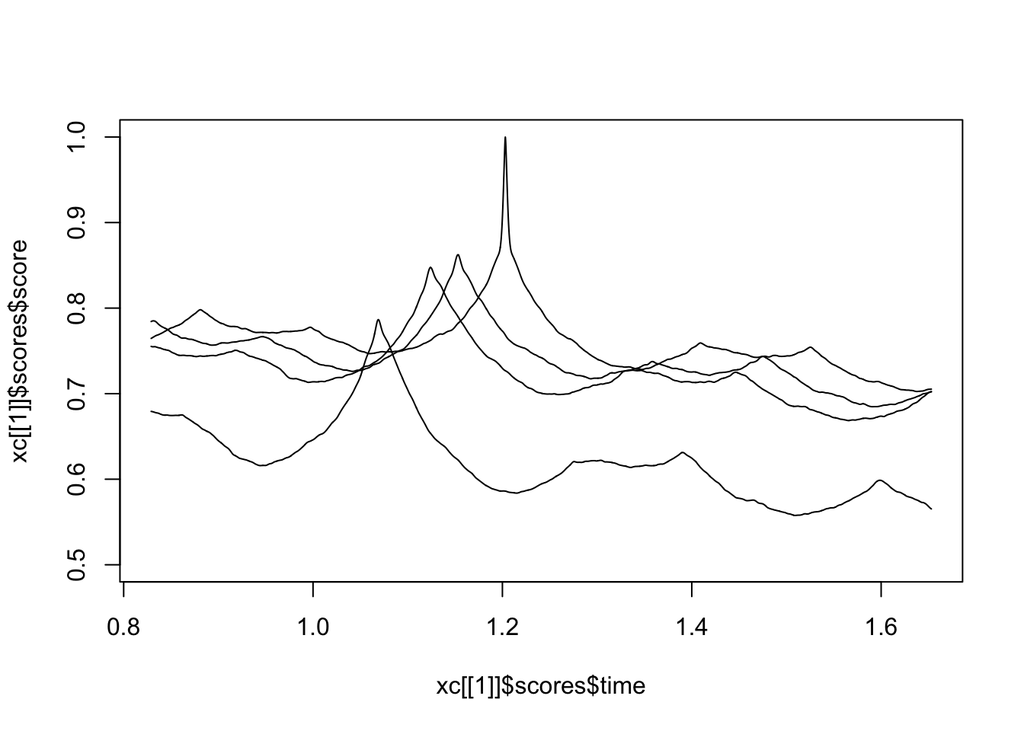

```r
load("xc_example.rdata")
plot(xc[[1]]$scores$time, xc[[1]]$scores$score, type="l", ylim=c(0.5,1))
points(xc[[2]]$scores$time, xc[[2]]$scores$score, type="l", ylim=c(0.5,1))
points(xc[[3]]$scores$time, xc[[3]]$scores$score, type="l", ylim=c(0.5,1))
points(xc[[4]]$scores$time, xc[[4]]$scores$score, type="l", ylim=c(0.5,1))
points(xc[[5]]$scores$time, xc[[5]]$scores$score, type="l", ylim=c(0.5,1))
```

What the script above does is save the “peak correlation score” (the apex of the “point” you see in each line) and the time (# of seconds from the beginning of the recording). The differences in these times are used as the relative delays in the arrival of the sound to each microphone.

But there are cases where the cross-correlation doesn’t always generate a clear peak… This is something we need to solve.

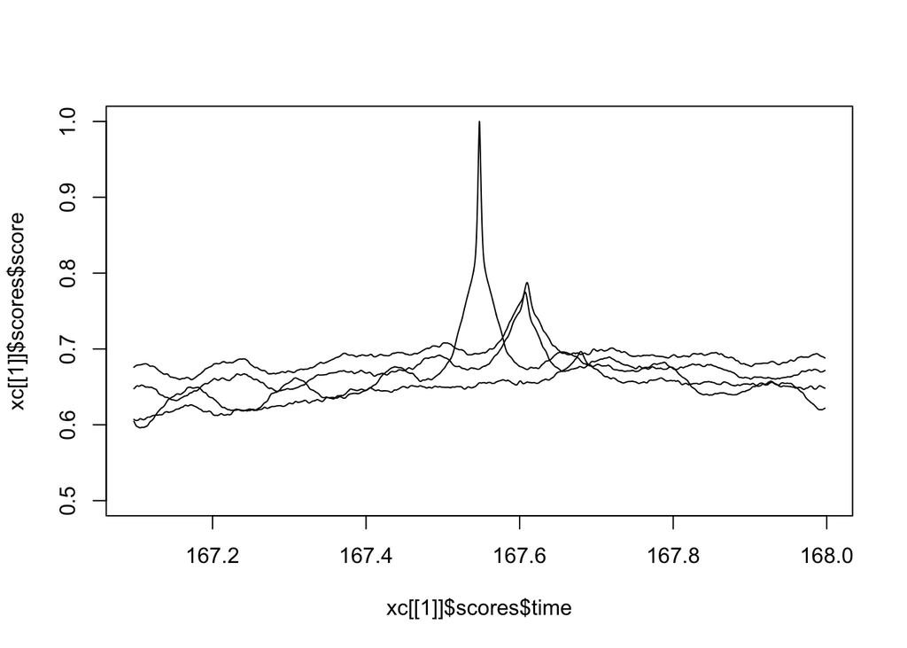

```r
load("xc_example__2.rdata")
plot(xc[[1]]$scores$time, xc[[1]]$scores$score, type="l", ylim=c(0.5,1))
points(xc[[2]]$scores$time, xc[[2]]$scores$score, type="l", ylim=c(0.5,1))
points(xc[[3]]$scores$time, xc[[3]]$scores$score, type="l", ylim=c(0.5,1))
points(xc[[4]]$scores$time, xc[[4]]$scores$score, type="l", ylim=c(0.5,1))
points(xc[[5]]$scores$time, xc[[5]]$scores$score, type="l", ylim=c(0.5,1))
```

Here is what the result would look like for one sound:

```r
load("Microphone Array_Analysis/control_MC20210615$071000_bambi/xcorr.results_99_bpfilter.rdata")
result.df[[1]]
```

```
##   trial call_type annotated_mic                template channel peak.time
## 1     1     check             3 MC20210615$071000-1.wav       1  3.141999
## 2     1     check             3 MC20210615$071000-1.wav       2  3.262294
## 3     1     check             3 MC20210615$071000-1.wav       3  3.213410
## 4     1     check             3 MC20210615$071000-1.wav       4  3.081736
## 5     1     check             3 MC20210615$071000-1.wav       5  3.275299
##   peak.score
## 1  0.6362072
## 2  0.6801552
## 3  0.9999942
## 4  0.6277509
## 5  0.6720507
```

Note that the peak score for one of the channels should be really high, approaching 1 (in this case, Channel 3). This would be the channel that the template sound was taken from.

## 5. Using Sound Finder to localize sounds

### 5.1. Install Sound Finder

Here, we will use the R package *SoundFinder*[^1] to estimate the source location of each sound.

To install SoundFinder, you will need to download the package from the supplemental materials of the paper: http://dx.doi.org/10.1080/09524622.2013.827588. Download the tar.gz file into the working directory and run the following code:

```r
install.packages("SoundFinder_1.0.tar.gz", repos = NULL, type ='source')
```

### 5.2. Set up the process

Now load the libraries you need.

```r
library(SoundFinder)
library(tidyverse)
library(stringr)
library(geodist)
#library(rgdal)
library(sf)
library(sp)
library(RColorBrewer)
library(ggplot2)
```

Load one of the result data from the cross-correlations in Part 4: (will need to change the path depending on your file structure)

Here, I have all of the results of each trial stored in separate folders within a subfolder called “Microphone Array_Analysis”. The subfolder names that start with “MC”, followed by “date$time_site”. For example, a trial for June 15, 2021 starting at 07:10:00am at Bambi is: “MC20210615$071000_bambi”

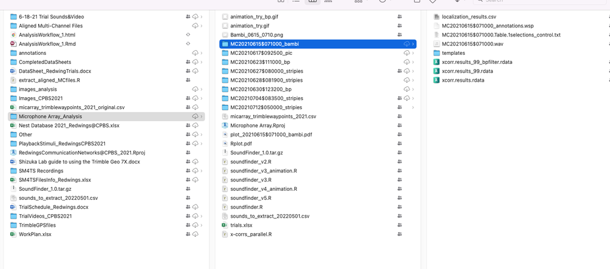

To extract the .rdata file:

```r
folders=list.files("Microphone Array_Analysis", pattern="MC")
use.folder=folders[3] #use the first folder. Change this to go through different folders.
use.colony=str_sub(use.folder,str_locate_all(use.folder, "_")[[1]][2,1]+1) #find "_" in the folder name and extract what comes after that.
load(paste("Microphone Array_Analysis", use.folder, "xcorr.results_99_bpfilter.rdata", sep="/"))
```

Now, you need to load the microphone coordinates. Here, I’ve stored this info on a .csv file

```r
mic.positions.dat=read.csv("Microphone Array_Analysis/micarray_trimblewaypoints_2021.csv")
mic.positions.dat
```

```
##           Site.Name     SITE POSITION      long      lat
## 1             Bambi    bambi        1 -101.6341 41.21181
## 2             Bambi    bambi        2 -101.6336 41.21186
## 3             Bambi    bambi        3 -101.6337 41.21172
## 4             Bambi    bambi        4 -101.6343 41.21170
## 5             Bambi    bambi        5 -101.6339 41.21177
## 6       Beaver Pond       bp        1 -101.6361 41.21399
## 7       Beaver Pond       bp        2 -101.6357 41.21397
## 8       Beaver Pond       bp        3 -101.6356 41.21367
## 9       Beaver Pond       bp        4 -101.6361 41.21364
## 10      Beaver Pond       bp        5 -101.6358 41.21382
## 11       Deep Water     deep        1 -101.6570 41.22056
## 12       Deep Water     deep        2 -101.6563 41.22013
## 13       Deep Water     deep        3 -101.6565 41.22004
## 14       Deep Water     deep        4 -101.6570 41.22043
```

[output cut: 63 more lines]

extract the mic positions for the site for the folder you selected above:

```r
mic.pos.use=mic.positions.dat[which(mic.positions.dat$SITE==use.colony),]
mic.pos.use
```

```
##      Site.Name SITE POSITION      long      lat inside.microphone  X
## 6  Beaver Pond   bp        1 -101.6361 41.21399             right NA
## 7  Beaver Pond   bp        2 -101.6357 41.21397              left NA
## 8  Beaver Pond   bp        3 -101.6356 41.21367             right NA
## 9  Beaver Pond   bp        4 -101.6361 41.21364              left NA
## 10 Beaver Pond   bp        5 -101.6358 41.21382              <NA> NA
```

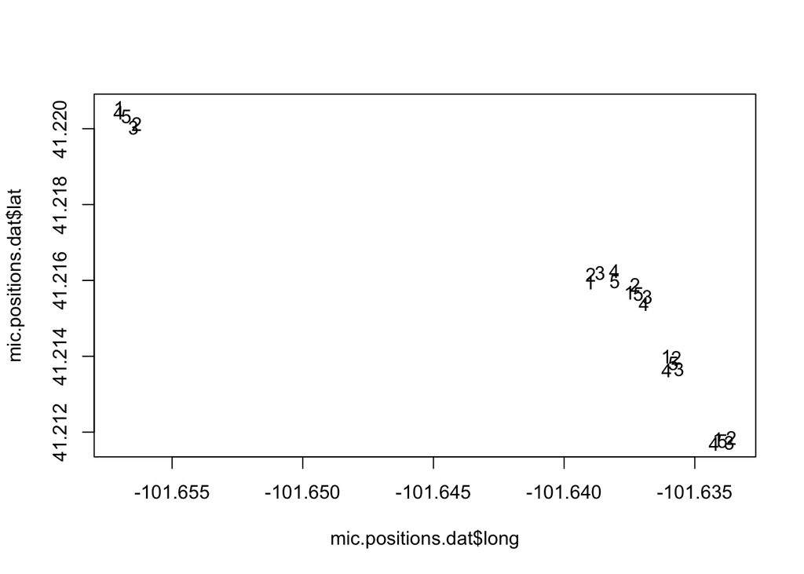

```r
plot(mic.positions.dat$long, mic.positions.dat$lat, type="n")
text(mic.positions.dat$long, mic.positions.dat$lat, labels=mic.positions.dat$POSITION)
```

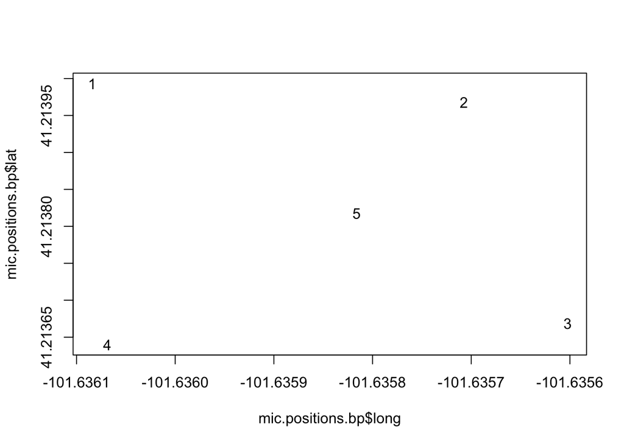

```r
mic.positions.bp=mic.positions.dat[which(mic.positions.dat$SITE=="bp"),]
plot(mic.positions.bp$long, mic.positions.bp$lat, type="n")
text(mic.positions.bp$long, mic.positions.bp$lat, labels=mic.positions.bp$POSITION)
```

Now, convert the longitude and latitude info for the mic positions into utm. I **THINK** I did this correctly… though I am not 100% sure because the latitude and longitude seemed like they were transposed when I plotted it…

```r
coords=SpatialPoints(cbind(mic.pos.use$long, mic.pos.use$lat), proj4string = CRS("+proj=longlat"))
coords.utm=spTransform(coords, CRS("+proj=utm + zone=14 +datum=WGS84"))
coords.utm.matrix=coords.utm@coords

coords.xy=as.data.frame(coords.utm.matrix)
#coords.xy[,1]=coords.xy[,1]-min(coords.xy[,1])
#coords.xy[,2]=coords.xy[,2]-min(coords.xy[,2])

names(coords.xy)=c("east", "north")
coords.xy
```

```
##       east   north
## 1 279009.4 4565864
## 2 279041.0 4565860
## 3 279048.8 4565826
## 4 279009.6 4565824
## 5 279031.3 4565843
```

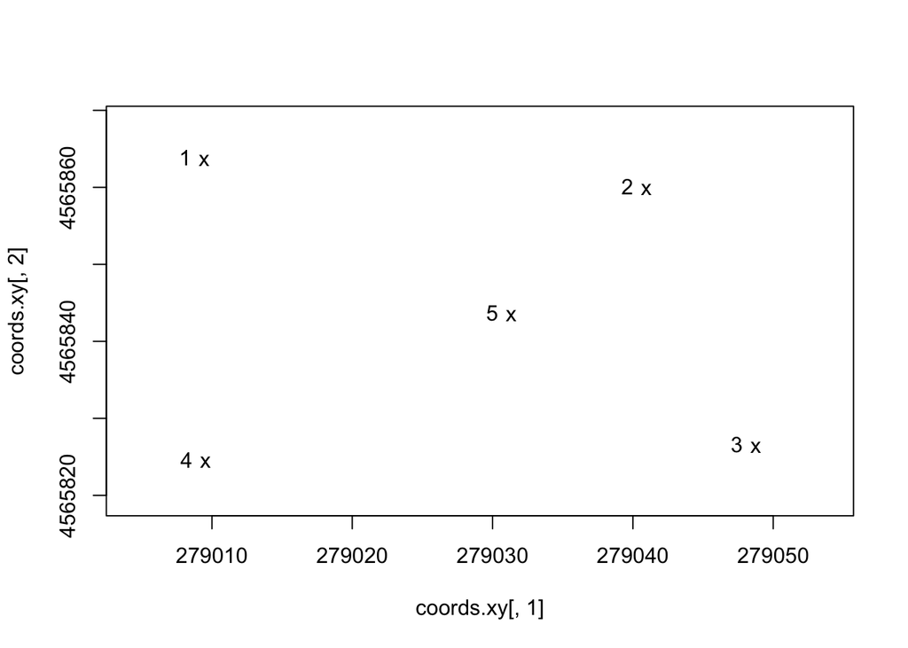

```r
plot(coords.xy[,1], coords.xy[,2], pch="x", xlim=c(min(coords.xy[,1]-5), max(coords.xy[,1]+5)), ylim=c(min(coords.xy[,2]-5), max(coords.xy[,2]+5)))
text(x=coords.xy[,1], y=coords.xy[,2], labels=1:5, pos=2)
```

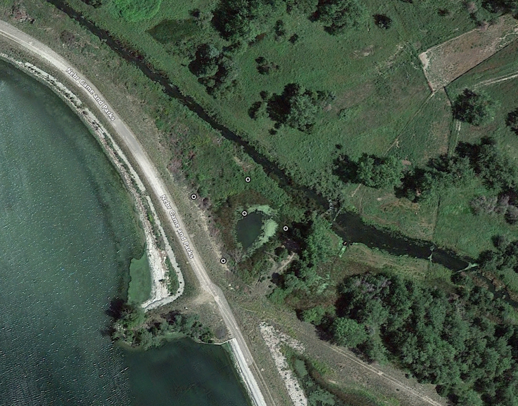

```r
knitr::include_graphics("images_analysis/site_bp.png")
```

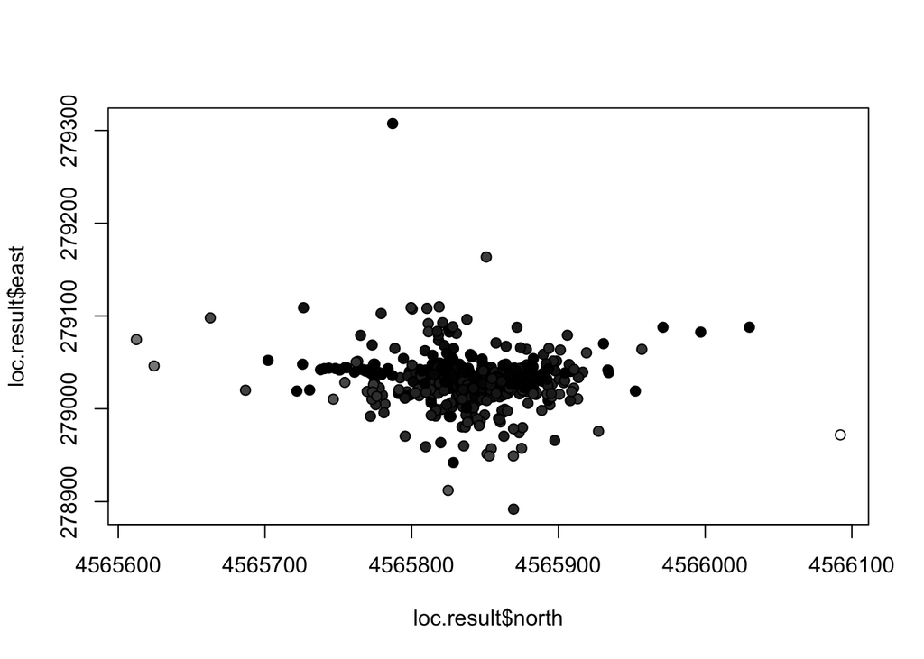

```r
sound.type=sapply(result.df, function(x) x$call_type[1])

sound.results=as.data.frame(t(sapply(result.df, function(x) x$peak.time)))
names(sound.results)=c("t1", "t2", "t3", "t4", "t5")
temps=rep(21.5, nrow(sound.results))

loc.result=localize(mics=coords.xy, sounds=sound.results, temps=temps)
loc.result$sound.type=sound.type
loc.result$low.peak.score=sapply(result.df, function(x) min(x$peak.score, na.rm=T))

plot(loc.result$north, loc.result$east, pch=21, bg=gray(loc.result$err.metres/max(loc.result$err.metres)))
```

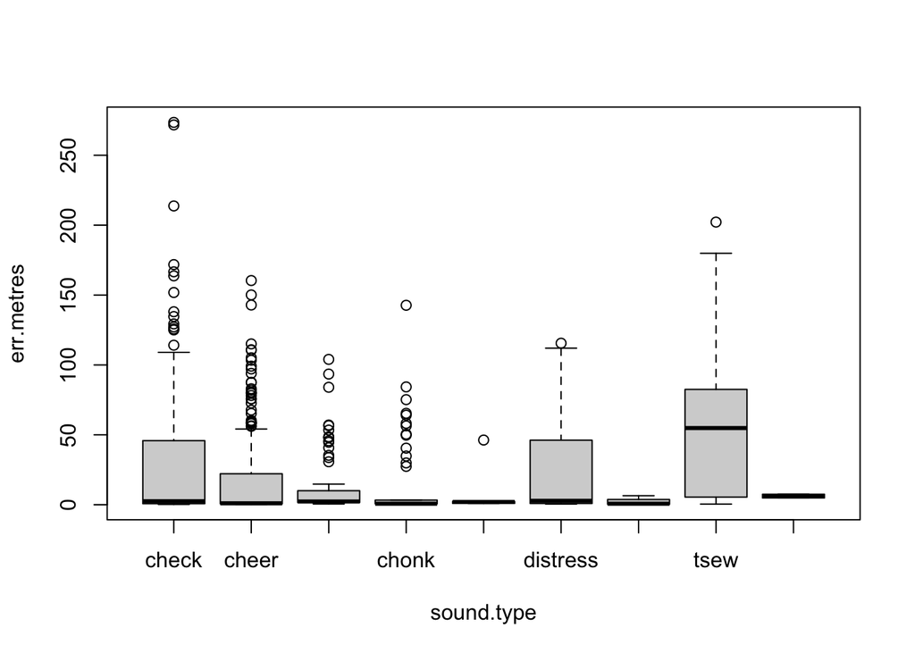

```r
plot(err.metres~sound.type, data=loc.result %>% filter(err.metres<500))
```

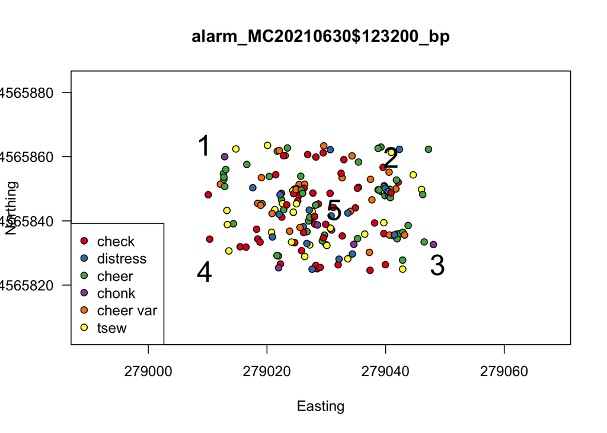

```r
rare.voc=names(which(table(loc.result$sound.type)<5))
loc.result.trim=loc.result %>%
  filter(!sound.type%in%rare.voc) %>%
  filter(north<max(coords.xy$north) & east<max(coords.xy$east) & north>min(coords.xy$north) & east>min(coords.xy$east))

# loc.result.trim=loc.result %>%
#   filter(sound.type!=rare.voc)

sound.type.color=data.frame(type=unique(factor(loc.result.trim$sound.type)), color=brewer.pal(length(unique(factor(loc.result.trim$sound.type))), "Set1"))


plot(loc.result.trim$east, loc.result.trim$north, pch=21, xlim=c(min(loc.result.trim$east-20), max(loc.result.trim$east+20)), ylim=c(min(loc.result.trim$north-20), max(loc.result.trim$north+20)), bg=sound.type.color[match(loc.result.trim$sound.type, sound.type.color$type), "color"], las=1, xlab="Easting", ylab="Northing", main=use.folder)
#points(coords.xy, pch="x", col="black", cex=2)
text(coords.xy$east, coords.xy$north,pch="x", col="black", cex=2, labels=rownames(coords.xy))
legend("bottomleft", legend=sound.type.color$type, pch=21, pt.bg=sound.type.color$color)
```

[^1]: Wilson, D.R., Battiston, M., Brzustowski, J., and Mennill, D.J. (2014) Sound Finder: a new software approach for localizing animals recorded with a microphone array. *Bioacoustics* 23:2, 99-112.